# Hackathon - Quelle(s) énergie(s) pour demain ?

Hiroto YAMAKAWA  
Thomas KOCH  
Thomas RIVIERE  
Philippe BENEZETH  
Xavier BRACQUART

> Sources utilisées :
> - https://www.bp.com/en/global/corporate/energy-economics/statistical-review-of-world-energy.html
> - https://jancovici.com/transition-energetique/charbon/a-quoi-sert-le-charbon/

Notre étude se restreindra principalement aux sources utilisées dans la production d'énergie (électricité et chauffage notamment). En effet, la production d'énergie est ce qui rejette le plus de CO2 au niveau mondial (voir https://ourworldindata.org/grapher/global-carbon-dioxide-emissions-by-sector) et il convient donc d'en comprendre les raisons. Nous verrons ainsi au cours de cette modeste étude, que le charbon en est l'une des causes les plus importante (voir aussi https://ourworldindata.org/grapher/co2-by-source).

```python
import numpy as np
import pandas as pd
import matplotlib.pyplot as plt
from plotly.offline import init_notebook_mode, iplot
init_notebook_mode(connected=False)
import seaborn as sns
```

## Introduction :

Commençons par nous intéresser aux évolutions des rejets de CO2 en fonction des sources de production.

```python
co2_df = pd.read_csv("CO2-by-source.csv")
co2_df = co2_df[~co2_df['Entity'].str.contains("World")]
co2_agg_df = co2_df.groupby(['Year']).sum()
```

```python
# Graphe des rejets de CO2
index = co2_agg_df.index
fig = go.Figure( )
fig.add_trace(go.Scatter(
    x=index, y= co2_df['Cement (tonnes)'].values,
    hoverinfo='x+y',
    mode='lines',
    line=dict(width=0.5),
    stackgroup='one', # define stack group
    name="Ciment"
))
fig.add_trace(go.Scatter(
    x=index, y= co2_agg_df['Flaring (tonnes)'].values,
    hoverinfo='x+y',
    mode='lines',
    line=dict(width=0.5),
    stackgroup='one',
    name="Flaring (pdt extraction du petrole)"
))
fig.add_trace(go.Scatter(
    x=index, y= co2_agg_df['Oil (tonnes)'].values,
    hoverinfo='x+y',
    mode='lines',
    line=dict(width=0.5),
    stackgroup='one',
    name="Pétrole"
))
fig.add_trace(go.Scatter(
    x=index, y= co2_agg_df['Coal (tonnes)'].values,
    hoverinfo='x+y',
    mode='lines',
    line=dict(width=0.5),
    stackgroup='one',
    name="Charbon"
))
fig.add_trace(go.Scatter(
    x=index, y= co2_agg_df['Gas (tonnes)'].values,
    hoverinfo='x+y',
    mode='lines',
    line=dict(width=0.5),
    stackgroup='one',
    name="Gaz"
))

fig.update_layout(title="Evolution des rejets de CO2",
    xaxis_title="Année",
    yaxis_title="Tonnes de CO2")
fig.show()
```

[interactive chart not shown]

Malgré cela, le charbon reste encore majoritairement utilisé pour produire de l'énergie :

```python
# Graphe des morts
xl = pd.ExcelFile("bp-stats-review-2019-all-data.xlsx")

def get_data_consumption(sheet_name):
    df = pd.read_excel("bp-stats-review-2019-all-data.xlsx", sheet_name=sheet_name, header=2,nrows=108, usecols=range(55))
    df = df.dropna(axis=0, how='all', thresh=None, subset=None, inplace=False)
    df = df[~df['Million tonnes oil equivalent'].str.contains("Total")]
    df = df.set_index("Million tonnes oil equivalent")
    df.index.name = None
    return df

df_oil_cons = get_data_consumption("Oil Consumption - Mtoe")
df_gas_cons = get_data_consumption("Gas Consumption - Mtoe")
df_coal_cons = get_data_consumption("Coal Consumption - Mtoe")
df_nucl_cons = get_data_consumption("Nuclear Consumption - Mtoe")
df_hydr_cons = get_data_consumption("Hydro Consumption - Mtoe")
df_renew_cons = get_data_consumption("Renewables - Mtoe")
```

```python
# Graphe sur l'utilisation du charbon pour la production d'électricité

import plotly.graph_objects as go

x=['Winter', 'Spring', 'Summer', 'Fall']

fig = go.Figure( )
fig.add_trace(go.Scatter(
    x=df_oil_cons.sum(axis=0).index, y= df_oil_cons.sum(axis=0).values,
    hoverinfo='x+y',
    mode='lines',
    line=dict(width=0.5),
    stackgroup='one', # define stack group
    name="Petrole"
))
fig.add_trace(go.Scatter(
    x=df_gas_cons.sum(axis=0).index, y= df_gas_cons.sum(axis=0).values,
    hoverinfo='x+y',
    mode='lines',
    line=dict(width=0.5),
    stackgroup='one',
    name="Gaz"
))
fig.add_trace(go.Scatter(
    x=df_coal_cons.sum(axis=0).index, y= df_coal_cons.sum(axis=0).values,
    hoverinfo='x+y',
    mode='lines',
    line=dict(width=0.5),
    stackgroup='one',
    name="Charbon"
))
fig.add_trace(go.Scatter(
    x=df_nucl_cons.sum(axis=0).index, y= df_nucl_cons.sum(axis=0).values,
    hoverinfo='x+y',
    mode='lines',
    line=dict(width=0.5),
    stackgroup='one',
    name="Nucléaire"
))
fig.add_trace(go.Scatter(
    x=df_hydr_cons.sum(axis=0).index, y= df_hydr_cons.sum(axis=0).values,
    hoverinfo='x+y',
    mode='lines',
    line=dict(width=0.5),
    stackgroup='one',
    name="Hydraulique"
))
fig.add_trace(go.Scatter(
    x=df_renew_cons.sum(axis=0).index, y= df_renew_cons.sum(axis=0).values,
    hoverinfo='x+y',
    mode='lines',
    line=dict(width=0.5),
    stackgroup='one',
    name="Renouvelable"
))

fig.update_layout(title="Production d'énergie par type de ressources au niveau mondial",
    xaxis_title="Années",
    yaxis_title="MTEP")
fig.show()
```

[interactive chart not shown]

De plus, pour chaque terawatt heures d'électricité produite, le charbon est de loin la plus meurtrière des énergies. La production d'électricité à partir du charbon génère en effet d'importants rejets de CO2 qui entraînent des maladies conduisant à des décès.

```python
df = pd.read_csv("death-rates-from-energy-production-per-twh.csv")

import plotly.express as px
fig = px.bar(df.sort_values(by =' (deaths per TWh)', ascending = False), x='Entity', y=' (deaths per TWh)', category_orders={})
fig.show()
```

[interactive chart not shown]

## 1. Quels sont les principaux pays consommateurs de charbon ?

Contrairement à une idée reçue, le charbon n’est pas seulement une énergie des pays « pauvres » ou « émergents », mais aussi… une énergie des pays dits riches, car ces derniers possèdent aussi des centrales électriques à charbon. Les USA ne sont pas le seul pays industrialisé à consommer du charbon significativement : parmi les 25 premiers consommateurs de charbon par personne se trouvent beaucoup de pays de l’OCDE :

```python
iso_code = pd.read_csv('sql-pays.csv', header=None)
df_coal_cons_map = df_coal_cons.join(iso_code.set_index(5))
df_coal_cons_map.at[ 'US', 3] = 'USA'
df_coal_cons_map.at[ 'South Korea', 3] = 'KOR'
df_coal_cons_map = df_coal_cons_map.dropna(subset=[3])
```

```python
# Graphe des consommateurs de charbon par personne
fig = go.Figure(data=go.Choropleth(
    locations = df_coal_cons_map[3],
    z = df_coal_cons_map[2018],
    text = coal_production_2014.index,
    colorscale = 'Hot',
    reversescale=True,
    marker= go.choropleth.Marker(
    line=go.choropleth.marker.Line(
    color = 'rgb(180,180,180)',
    width=0.5)),
    #colorbar_tickprefix = '$',
    colorbar_title = 'Production en TWH',
    ),
    layout= go.Layout(
        title = 'Consommation de charbon par pays en 2014',
        geo = go.layout.Geo(
        showframe=False,
        showcoastlines=False,
        projection= go.layout.geo.Projection(type='equirectangular'))))
iplot(fig)
```

[interactive chart not shown]

```python
df_consumption_coal = pd.read_csv("coal-consumption-per-capita.csv")
df_consumption_coal = df_consumption_coal.rename(columns={"Coal consumption per capita (BP & UN (2017 revision)) (megawatt-hours)": "coal_consumption_per_capita"})

year_range = df_consumption_coal[df_consumption_coal["Entity"]== 'Africa'].Year

Conso_Africa = df_consumption_coal[df_consumption_coal["Entity"]== 'Africa'].coal_consumption_per_capita
Conso_India = df_consumption_coal[df_consumption_coal["Entity"]== 'India'].coal_consumption_per_capita
Conso_China = df_consumption_coal[df_consumption_coal["Entity"]== 'China'].coal_consumption_per_capita
Conso_World = df_consumption_coal[df_consumption_coal["Entity"]== 'World'].coal_consumption_per_capita
Conso_USA = df_consumption_coal[df_consumption_coal["Entity"]== 'United States'].coal_consumption_per_capita
Conso_Taiwan = df_consumption_coal[df_consumption_coal["Entity"]== 'Taiwan'].coal_consumption_per_capita
Conso_Indonesia = df_consumption_coal[df_consumption_coal["Entity"]== 'Indonesia'].coal_consumption_per_capita
```

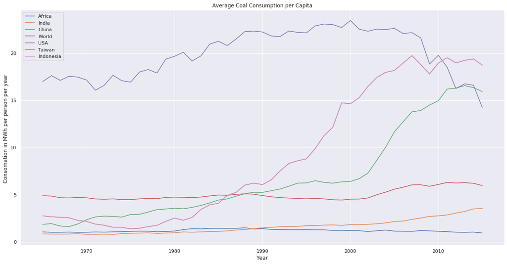

```python
x= year_range
sns.set()
plt.figure(figsize=(20, 10))
plt.plot(x,Conso_Africa, label = 'Africa')
plt.plot(x,Conso_India, label = 'India')
plt.plot(x,Conso_China, label = 'China')
plt.plot(x,Conso_World, label = 'World')
plt.plot(x,Conso_USA, label = 'USA')
plt.plot(x,Conso_Taiwan, label = 'Taiwan')
plt.plot(x,Conso_Taiwan, label = 'Indonesia')
#plt.plot(x,Conso_Russia, label = 'Russia')

plt.title ('Average Coal Consumption per Capita')
plt.ylabel("Consomation in MWh per person per year ")
plt.xlabel("Year")
plt.legend(loc = "upper left")
plt.show()
```

## 2. Pourquoi le charbon est-il autant utilisé ?

Le côut d'extraction du charbon est relativement faible, les réserves sont facilement disponibles, notamment dans les pays qui l'utilisent beaucoup et ces pays doivent pouvoir faire face à la demande croissante en énergie accentuée par l'augmentation de la population mondiale.

```python
pd.read_csv("coal-production-by-country.csv")['Entity'].unique()
coal_production = pd.read_csv("coal-production-by-country.csv")
coal_production_2014 = coal_production[coal_production["Year"] == 2014]
```

```python
# Graphe sur les pays producteurs de charbon en 2014
fig = go.Figure(data=go.Choropleth(
    locations = coal_production_2014['Code'],
    z = coal_production_2014['  (terawatt-hours)'],
    text = coal_production_2014['Entity'],
    colorscale = 'Hot',
    reversescale=True,
    marker= go.choropleth.Marker(
    line=go.choropleth.marker.Line(
    color = 'rgb(180,180,180)',
    width=0.5)),
    #colorbar_tickprefix = '$',
    colorbar_title = 'Production en TWH',
    ),
    layout= go.Layout(
        title = 'Production de charbon par pays en 2014',
        geo = go.layout.Geo(
        showframe=False,
        showcoastlines=False,
        projection= go.layout.geo.Projection(type='equirectangular'))))
iplot(fig)
```

[interactive chart not shown]

Evolution de la population mondiale :

```python
url = "world-population-by-world-regions-post-1820.csv"

df_population = pd.read_csv(url)

df_popu_growth= df_population[df_population['Code'].isna()]
df_popu_growth_from_1900 = df_popu_growth[df_popu_growth['Year'] > 1900].sort_values(by = "Population")
df_popu_growth_from_1900= df_popu_growth_from_1900[df_popu_growth_from_1900['Entity']!= "Saint Barthlemy"] #

# Data
pop_Asia = df_popu_growth_from_1900[df_popu_growth_from_1900['Entity'] == 'Asia'].Population
pop_Africa = df_popu_growth_from_1900[df_popu_growth_from_1900['Entity'] == 'Africa'].Population
pop_Europe = df_popu_growth_from_1900[df_popu_growth_from_1900['Entity'] == 'Europe'].Population
pop_Latin_America = df_popu_growth_from_1900[df_popu_growth_from_1900['Entity'] == 'Latin America'].Population
pop_North_America = df_popu_growth_from_1900[df_popu_growth_from_1900['Entity'] == 'North America'].Population
pop_Oceania = df_popu_growth_from_1900[df_popu_growth_from_1900['Entity'] == 'Oceania'].Population
```

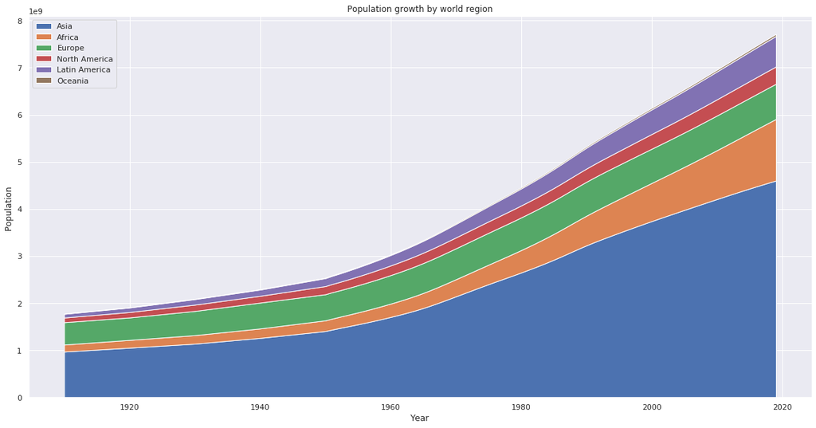

```python
# Graphe sur l'évolution de la population
sns.set()
x = df_popu_growth_from_1900[df_popu_growth_from_1900['Entity'] == 'Asia'].Year  # pour recuperer les annees de 1910 à 2019
y = [pop_Asia, pop_Africa, pop_Europe, pop_North_America, pop_Latin_America, pop_Oceania]

plt.figure(figsize=(20,10))
plt.stackplot(x,y, labels=['Asia','Africa','Europe','North America', 'Latin America', 'Oceania'])
plt.legend(loc='upper left')
plt.title ('Population growth by world region')
plt.ylabel("Population ")
plt.xlabel("Year")

plt.show()
```

## 3. Une diminution de l'utilisation du charbon est-elle à entrevoir ?

En 2015, de nombreux pays ont massivement investi dans les énergies renouvelables.

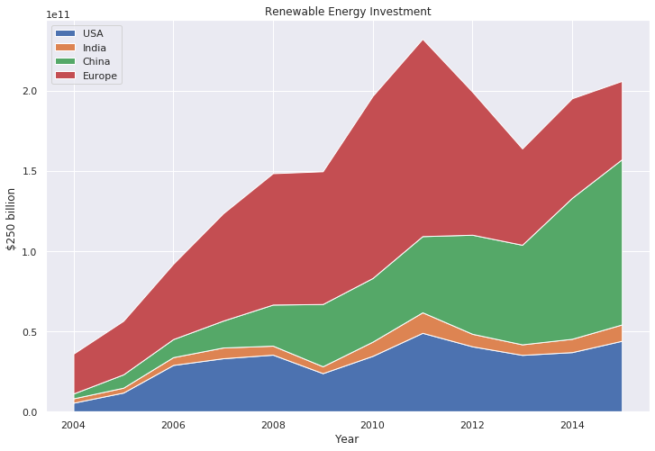

```python
#CSV
df_ren_investment = pd.read_csv("renewable-energy-investment.csv")
df_ren_investment = df_ren_investment.rename(columns={"Investment in Renewables by Region (IRENA (2016)) (international-$)": "investment"})

#DATA
year = df_ren_investment[df_ren_investment['Entity'] == "India"].Year
df_ren_investment_Europe = df_ren_investment[df_ren_investment['Entity'] == "Europe"].investment
df_ren_investment_USA = df_ren_investment[df_ren_investment['Entity'] == "United States of America"].investment
df_ren_investment_India = df_ren_investment[df_ren_investment['Entity'] == "India"].investment
df_ren_investment_China = df_ren_investment[df_ren_investment['Entity'] == "China"].investment

sns.set()
x=year  # pour recuperer les annees de 1910 à 2019
y=[df_ren_investment_USA,df_ren_investment_India, df_ren_investment_China, df_ren_investment_Europe ]

#PLOT
plt.figure(figsize=(12, 8))
plt.stackplot(x,y, labels=['USA','India','China','Europe'])
plt.legend(loc='upper left')
plt.title ('Renewable Energy Investment')
plt.ylabel("$250 billion ")
plt.xlabel("Year")
plt.show()
```

Certains secteurs ont été privilégiés comme le **solaire** ou **l'éolien**.

```python
import plotly.graph_objects as go
invest = pd.read_csv('investment-in-renewable-energy-by-technology.csv',sep=',')
l = invest

l[1] = invest['Marine Energy (USD)']
l[2] = invest['Geothermal Energy (USD)']
l[3] = invest['Small Hydropower (USD)']
l[4] = invest['Liquid Biofuels (USD)']
l[5] = invest['Biomass & Waste-to-Energy (USD)']
l[6] = invest['Wind Energy (USD)']
l[7] = invest['Solar Energy (USD)']

for i in range(1,8):
    l[i] = l[i]/1000000000


x=list(np.arange(2004,2017))
fig = go.Figure(go.Bar(x=x, y=l[7], name='Solar Energy'))
fig.add_trace(go.Bar(x=x, y=l[6], name='Wind Energy'))
fig.add_trace(go.Bar(x=x, y=l[5], name='Biomass & Waste-to-Energy'))
fig.add_trace(go.Bar(x=x, y=l[4], name='Liquid Biofuels'))
fig.add_trace(go.Bar(x=x, y=l[3], name='Small Hydropower'))
fig.add_trace(go.Bar(x=x, y=l[2], name='Geothermal Energy'))
fig.add_trace(go.Bar(x=x, y=l[1], name='Marine Energy'))

#fig.update_layout(barmode='stack', xaxis={'categoryorder':'category ascending'})
fig.update_layout(barmode='stack')
fig.update_layout(title="Investment in renewable energy, by technology",
    xaxis_title="Année",
    yaxis_title="Investment in $ billion")

fig.update_layout(
    title={
        'text': "Investment in renewable energy, by technology",
        'x':0.5,
        'xanchor': 'center',
        'yanchor': 'top'})

fig.show()
```

[interactive chart not shown]

### Transition vers d'autres sources ?

```python
df = pd.read_csv("world-electricity-by-source.csv")
not_countries = ["European Union","Euro area","Sub-Saharan Africa (excluding high income)","Sub-Saharan Africa (IDA & IBRD)", "High income", "Middle East & North Africa (IDA & IBRD)","Sub-Saharan Africa","OECD members","Central Europe and the Baltics","Low income","Post-demographic dividend","IDA blend","Middle East & North Africa (excluding high income)","Middle East & North Africa","South Asia (IDA & IBRD)","Middle East & North Africa (IDA & IBRD)","IDA total","IDA only","Latin America & Caribbean (excluding high income)","Latin America & Caribbean","Latin America & Caribbean (IDA & IBRD)","Small states","Other small states","Early-demographic dividend","East Asia & Pacific (IDA & IBRD)","World", "East Asia & Pacific (excluding high income)","IDA & IBRD total","IBRD only","South Asia (IDA & IBRD","Upper middle income","Low & middle income","Middle income","Late-demographic dividend","East Asia & Pacific","Lower middle income"]
df.columns = ['Entity', 'Code', 'Year', 'Coal', 'Nuclear','Natural_gas', 'Oil', 'Hydroelectric', 'Other_renewables']
df.drop(columns=['Code'], inplace=True)

df_1971_2015 = df[(df["Year"] == 1975) | (df["Year"] == 2015)]
df_unstack = df_1971_2015.set_index(['Entity', 'Year']).unstack()
df_unstack

df_unstack["Difference", "Coal"] = df_unstack["Coal"][2015] - df_unstack["Coal"][1975]
df_unstack["Difference", "Nuclear"] = df_unstack["Nuclear"][2015] - df_unstack["Nuclear"][1975]
df_unstack["Difference", "Natural_gas"] = df_unstack["Natural_gas"][2015] - df_unstack["Natural_gas"][1975]
df_unstack["Difference", "Oil"] = df_unstack["Oil"][2015] - df_unstack["Oil"][1975]
df_unstack["Difference", "Hydroelectric"] = df_unstack["Hydroelectric"][2015] - df_unstack["Hydroelectric"][1975]
df_unstack["Difference", "Other_renewables"] = df_unstack["Other_renewables"][2015] - df_unstack["Other_renewables"][1975]

df_difference = df_unstack.drop(columns=["Coal", "Nuclear", "Natural_gas", "Oil", "Hydroelectric", "Other_renewables"])
df_difference.columns = df_difference.columns.droplevel()
df_difference.columns.name = ""
df_difference.sort_values(by="Coal", inplace=True)
df_difference.fillna(0, inplace=True)
df_difference.drop(not_countries, axis=0, errors="ignore", inplace=True)
```

```python
pd.options.mode.chained_assignment = None

df_decrease_coal = df_difference[df_difference["Coal"] < -5]
df_decrease_coal.drop(columns=["Coal"], inplace=True)
df_decrease_coal[df_decrease_coal < 0] = 0
df_decrease_coal = df_decrease_coal.apply(lambda x: round(x/x.sum(),2), axis=1)
df_decrease_coal["New_source"] = df_decrease_coal.idxmax(axis=1)
df_decrease_coal = df_decrease_coal.reset_index().sort_values("New_source").set_index(["New_source", "Entity"])

df_decrease_count = df_decrease_coal.reset_index().groupby("New_source").count()["Entity"].sort_values(ascending=False)

fig = go.Figure([go.Bar(x=df_decrease_count.index, y=df_decrease_count.values)])
fig.show()
```

[interactive chart not shown]

### Augmentation du charbon au détriment d'autres sources ?

```python
df_increase_coal = df_difference[df_difference["Coal"] > 5]
df_increase_coal.drop(columns=["Coal"], inplace=True)
df_increase_coal[df_increase_coal > 0] = 0
df_increase_coal = df_increase_coal.apply(lambda x: round(x/x.sum(),2), axis=1)
df_increase_coal["Old_source"] = df_increase_coal.idxmax(axis=1)
df_increase_coal = df_increase_coal.reset_index().sort_values("Old_source").set_index(["Old_source", "Entity"])
df_increase_count = df_increase_coal.reset_index().groupby("Old_source").count()["Entity"].sort_values(ascending=False)

fig = go.Figure([go.Bar(x=df_increase_count.index, y=df_increase_count.values)])
fig.show()
```

[interactive chart not shown]

## Conclusion / Ouverture

Il est logique que le charbon ait pris une telle place dans un contexte socio-économique où les avantages immédiats écrasent les inconvénients à long terme. Avec un système de formation des prix qui ne tient que très peu compte de la rareté à long terme et des dommages environnementaux de long terme, mais beaucoup du coût immédiat du travail, le charbon est un ticket gagnant :

- il est abondant, et surtout disponible sur place dans les pays qui dominent l’économie mondiale (à l’exception du Japon),
- il n’est pas cher à extraire : 40 à 50 dollars la tonne, soit 0,5 à 1 centime d’euro le kWh (comme pour le pétrole),
- il est nécessaire – ou le moins cher – pour la production de tous les matériaux de base qui ont fait l’essor de la société industrielle,
- il permet de produire de l’électricité pour pas cher, or l’électricité est la forme la plus noble (et donc la plus polyvalente), sur le plan thermodynamique, des énergies finales que nous utilisons.

Avec plus de 500 milliards de tonnes de réserves prouvées, le charbon serait la dernière des énergies carbonées disponibles si la croissance de la consommation continuait comme aujourd’hui. Alors que le pic de production du pétrole est proche, et qu’il en sera de même pour le gaz bien avant le milieu du siècle, accélérer le recours au charbon deviendra probablement de plus en plus tentant tant que le monde cherchera la « croissance économique » à court terme, même si cela doit s’accompagner d’une forte prise de risque concernant des dégâts climatiques ultérieurs (et d’une décroissance économique accélérée à ce moment là !). Car l’usage de cette énergie est synonyme de fortes émissions de gaz à effet de serre…

**Toutefois, on constate que la transition avec de nouvelles énergies est en marche puisque des pays ont investis massivement dans les énergies renouvelables. Reste maintenant à savoir si ces investissements permettront de répondre aux besoins croissants en énergie, ce qui est moins sûr.**